# RQ1 (part B): heatmap of DEGs, GSEA and leading-edge genes

22123 Computational Precision Medicine — group 9

Author

Manuel Charneca

Published

November 25, 2026

## Overview

- **Input:** `results/DE_R_vs_NR_all.csv` and `results/processed_shared.rds` (written by script 01)
- **Output:** figures in `results/figures/` and tables `results/gsea_*.csv`
- **Run order:** source `scripts/01_load_qc_deseq2.R` first, then render this file.
- **AI disclosure:** AI was used to help define the settings, aesthetics and formatting of the plots and to fix bugs.

```r
suppressPackageStartupMessages({
  library(fgsea)
  library(msigdbr)
  library(pheatmap)
  library(ggplot2)
  library(data.table)
})

set.seed(22123)
dir.create("results/figures", recursive = TRUE, showWarnings = FALSE)
theme_set(theme_bw(base_size = 12))
pal     <- c(NR = "#7F7F7F", R = "#D55E00")
dir_pal <- c("up in R" = "#D55E00", "down in R" = "#0072B2")
```

## 1. Load the shared outputs of script 01

```r
# Load the DESeq2 results and remove gene without name
de       <- read.csv("results/DE_R_vs_NR_all.csv")
de <- de[!is.na(de$gene) & de$gene != "", ]
shared   <- readRDS("results/processed_shared.rds")
vst      <- shared$vst
clinical <- shared$clinical

# Keep only the differentially expressed genes (DEGs) and split them into up/down in R
sig <- subset(de, direction != "not significant")
up  <- sig[sig$direction == "up in R", ]
dn  <- sig[sig$direction == "down in R", ]

#number of DEGs in each direction
cat("DEGs: up in Responders =", nrow(up), "| down in Responders =", nrow(dn), "\n")
```

```
DEGs: up in Responders = 73 | down in Responders = 204
```

## 2. Heatmap of selected DEGs

2 Heatmaps of the top 20 up and top 20 down DEGs by adjusted p-value. In both heatmaps, genes (rows) are ordered by hierarchical clustering: genes that are high and low in the same patients are placed next to each other.

The two heatmaps differ only in how the patients (columns) are ordered: a) **Ordered**: by response: responders first, then non-responders, b) **Clustered**: patients are grouped by the similarity of their expression, without using their response labels.

```r
#Top 20 Up/down genes
n_each    <- 20
top_genes <- c(head(up$gene[order(up$padj)], n_each),
               head(dn$gene[order(dn$padj)], n_each))

# Z-score each gene across patients (relative high/low) and cap at ±3 so a few extreme samples do not wash out the colour scale
zscore <- function(m, cap = 3) {
  z <- t(scale(t(m)))
  pmin(pmax(z, -cap), cap)
}

#Plot anotations and colors
ann_row    <- data.frame(Direction = ifelse(top_genes %in% up$gene, "up in R", "down in R"),
                         row.names = top_genes)
ann_colors <- list(Response = pal, Direction = dir_pal)
hm_colors  <- colorRampPalette(c("#2166AC", "white", "#B2182B"))(101)
hm_breaks  <- seq(-3, 3, length.out = 102)

# (a) Patients ordered by response (R first)
ord <- order(clinical$BOR, decreasing = TRUE)
mat <- zscore(vst[top_genes, ord])
hm1 <- pheatmap(mat,
         cluster_rows = TRUE, cluster_cols = FALSE,
         gaps_col = sum(clinical$BOR == "R"),
         show_colnames = FALSE, fontsize_row = 7,
         annotation_col = data.frame(Response = clinical$BOR[ord], row.names = colnames(mat)),
         annotation_row = ann_row, annotation_colors = ann_colors,
         color = hm_colors, breaks = hm_breaks,
         main = "Top 20 up + top 20 down DEGs (VST, z-score per gene)",
         filename = "results/figures/heatmap_DEGs_by_response.png",
         width = 9, height = 8)

# (b) Patients clustered by expression: do responders group together on their own?
mat2 <- zscore(vst[top_genes, ])
hm2 <- pheatmap(mat2,
         cluster_rows = TRUE, cluster_cols = TRUE,
         show_colnames = FALSE, fontsize_row = 7,
         annotation_col = data.frame(Response = clinical$BOR, row.names = colnames(mat2)),
         annotation_row = ann_row, annotation_colors = ann_colors,
         color = hm_colors, breaks = hm_breaks,
         main = "Same genes, patients clustered",
         filename = "results/figures/heatmap_DEGs_clustered.png",
         width = 9, height = 8)
```

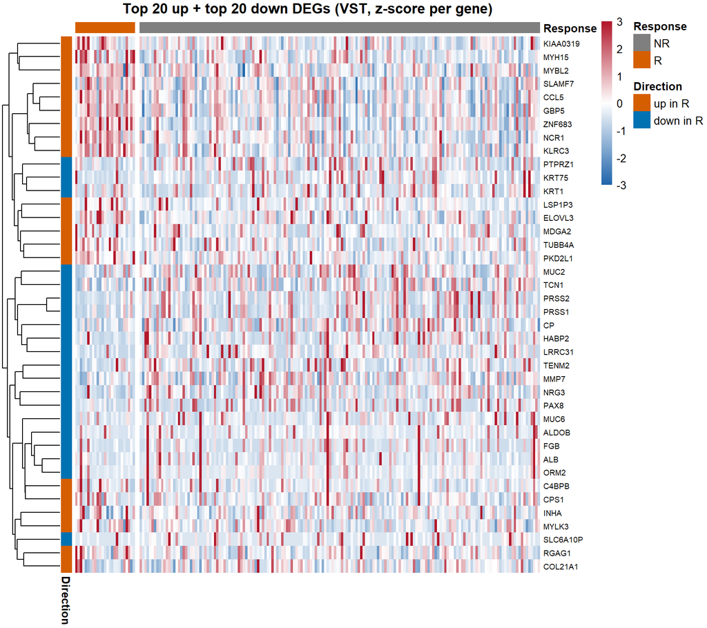

```r
# Draw the two heatmaps
grid::grid.newpage(); grid::grid.draw(hm1$gtable)
```

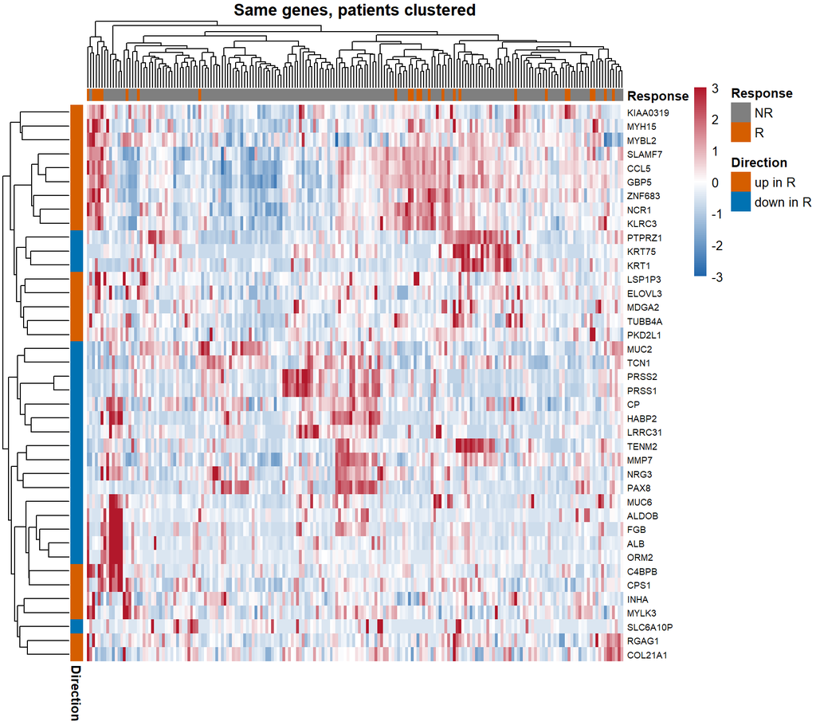

```r
grid::grid.newpage(); grid::grid.draw(hm2$gtable)
```

## 3. Gene set enrichment analysis (fgsea)

All tested genes are ranked by the DESeq2 Wald statistic (positive = higher in R). GSEA uses the full ranked list without a significance cut-off, which helps with only 25 responders. Two MSigDB collections were used: **GO:BP** (collapsed to reduce redundant gene sets) and **Hallmark** (50 broad, curated gene sets designed to avoid redundancy). For the top Hallmark sets we also list the leading-edge genes: the genes that drive each set’s enrichment.

```r
# Rank all genes by the DESeq2 Wald statistic
ranks <- setNames(de$stat, de$gene)
ranks <- sort(ranks, decreasing = TRUE)
cat("Genes in the ranked list:", length(ranks), "\n")
```

```
Genes in the ranked list: 17469
```

```r
# Get gene sets from MSigDB  and convert them to the list format needed by fgsea
gene_sets_h  <- msigdbr(species = "Homo sapiens", collection = "H")
gene_sets_h  <- split(x = gene_sets_h$gene_symbol, f = gene_sets_h$gs_name)
gene_sets_bp <- msigdbr(species = "Homo sapiens", collection = "C5", subcollection = "BP")
gene_sets_bp <- split(x = gene_sets_bp$gene_symbol, f = gene_sets_bp$gs_name)

# Run GSEA (fgsea) for Hallmark and GO:BP
set.seed(22123)
gsea_h  <- fgsea(pathways = gene_sets_h,  stats = ranks,
                 minSize = 15, maxSize = 500, nPermSimple = 10000)
set.seed(22123)
gsea_bp <- fgsea(pathways = gene_sets_bp, stats = ranks,
                 minSize = 15, maxSize = 500, nPermSimple = 10000)

# Summary: how many gene sets were tested and how many are significant
gsea_summary <- function(res, name) {
  sig_res <- res[padj < 0.05]
  cat(sprintf("%-8s gene sets tested: %d | padj < 0.05: %d (higher in R: %d, higher in NR: %d)\n",
              name, nrow(res), nrow(sig_res),
              sum(sig_res$NES > 0), sum(sig_res$NES < 0)))
}
gsea_summary(gsea_h,  "hallmark")
```

```
hallmark gene sets tested: 50 | padj < 0.05: 35 (higher in R: 15, higher in NR: 20)
```

```r
gsea_summary(gsea_bp, "gobp")
```

```
gobp     gene sets tested: 3878 | padj < 0.05: 1021 (higher in R: 368, higher in NR: 653)
```

```r
# Collapse overlapping GO:BP terms into independent main pathways
set.seed(22123)
collapsed <- collapsePathways(gsea_bp[order(pval)][padj < 0.05],gene_sets_bp, ranks)
bp_main   <- gsea_bp[pathway %in% collapsed$mainPathways]

# Show the 15 most significant Hallmark gene sets
knitr::kable(head(gsea_h[order(padj), .(pathway, NES, padj = signif(padj, 2), size)], 15),
             digits = 3, caption = "Top 15 Hallmark gene sets")
```

Top 15 Hallmark gene sets

| pathway | NES | padj | size |
| --- | --- | --- | --- |
| HALLMARK_E2F_TARGETS | 3.709 | 0 | 195 |
| HALLMARK_G2M_CHECKPOINT | 3.150 | 0 | 188 |
| HALLMARK_INTERFERON_GAMMA_RESPONSE | 2.976 | 0 | 195 |
| HALLMARK_MYC_TARGETS_V1 | 2.954 | 0 | 191 |
| HALLMARK_INTERFERON_ALPHA_RESPONSE | 3.024 | 0 | 95 |
| HALLMARK_COAGULATION | -2.683 | 0 | 125 |
| HALLMARK_EPITHELIAL_MESENCHYMAL_TRANSITION | -2.326 | 0 | 197 |
| HALLMARK_DNA_REPAIR | 2.401 | 0 | 146 |
| HALLMARK_HYPOXIA | -2.155 | 0 | 185 |
| HALLMARK_TNFA_SIGNALING_VIA_NFKB | -2.036 | 0 | 195 |
| HALLMARK_ALLOGRAFT_REJECTION | 2.054 | 0 | 185 |
| HALLMARK_MITOTIC_SPINDLE | 1.985 | 0 | 197 |
| HALLMARK_XENOBIOTIC_METABOLISM | -1.911 | 0 | 184 |
| HALLMARK_KRAS_SIGNALING_UP | -1.891 | 0 | 190 |
| HALLMARK_ANGIOGENESIS | -2.244 | 0 | 34 |

```r
# Show the 15 most significant collapsed GO:BP gene sets (for comparison with Hallmark)
knitr::kable(head(bp_main[order(padj), .(pathway, NES, padj = signif(padj, 2), size)], 15),
             digits = 3, caption = "Top 15 GO:BP main pathways (after collapsing)")
```

Top 15 GO:BP main pathways (after collapsing)

| pathway | NES | padj | size |
| --- | --- | --- | --- |
| GOBP_CHROMOSOME_SEGREGATION | 2.798 | 0 | 401 |
| GOBP_MITOTIC_SISTER_CHROMATID_SEGREGATION | 3.063 | 0 | 194 |
| GOBP_ORGANELLE_FISSION | 2.533 | 0 | 452 |
| GOBP_RIBONUCLEOPROTEIN_COMPLEX_BIOGENESIS | 2.458 | 0 | 464 |
| GOBP_DNA_REPLICATION | 2.732 | 0 | 292 |
| GOBP_DNA_RECOMBINATION | 2.650 | 0 | 291 |
| GOBP_MITOTIC_NUCLEAR_DIVISION | 2.687 | 0 | 276 |
| GOBP_DOUBLE_STRAND_BREAK_REPAIR | 2.641 | 0 | 284 |
| GOBP_DNA_TEMPLATED_DNA_REPLICATION | 2.944 | 0 | 163 |
| GOBP_CELL_CYCLE_CHECKPOINT_SIGNALING | 2.807 | 0 | 192 |
| GOBP_RECOMBINATIONAL_REPAIR | 2.775 | 0 | 173 |
| GOBP_REGULATION_OF_CELL_CYCLE_PHASE_TRANSITION | 2.252 | 0 | 436 |
| GOBP_MEMBRANELESS_ORGANELLE_ASSEMBLY | 2.263 | 0 | 417 |
| GOBP_MEIOTIC_CELL_CYCLE | 2.522 | 0 | 255 |
| GOBP_EXTERNAL_ENCAPSULATING_STRUCTURE_ORGANIZATION | -2.345 | 0 | 311 |

```r
# Where does the first immune term appear in the collapsed GO:BP list?
bp_up <- bp_main[NES > 0][order(padj)]
cat("First immune/interferon GO:BP term among those higher in R is at rank",
    which(grepl("INTERFERON|IMMUNE|T_CELL|LYMPHOCYTE", bp_up$pathway))[1], "\n")
```

```
First immune/interferon GO:BP term among those higher in R is at rank 25
```

```r
# Take the top 5 Hallmark sets higher in R and the top 5 higher in NR
top_h <- rbind(head(gsea_h[NES > 0][order(padj)], 5),
               head(gsea_h[NES < 0][order(padj)], 5))

# Table of the leading-edge genes genes driving enrichement and which of them are DEGs
le_tab <- data.frame(
  pathway         = top_h$pathway,
  NES             = round(top_h$NES, 2),
  padj            = signif(top_h$padj, 2),
  size            = top_h$size,
  n_leading       = lengths(top_h$leadingEdge),
  top_leading     = vapply(top_h$leadingEdge, function(g) paste(head(g, 15), collapse = ", "), ""),
  DEGs_in_leading = vapply(top_h$leadingEdge, function(g) paste(intersect(g, sig$gene), collapse = ", "), ""))
write.csv(le_tab, "results/gsea_hallmark_leading_edge.csv", row.names = FALSE)
knitr::kable(le_tab[, c("pathway", "NES", "padj", "n_leading", "top_leading")])
```

| pathway | NES | padj | n_leading | top_leading |
| --- | --- | --- | --- | --- |
| HALLMARK_E2F_TARGETS | 3.71 | 0.0e+00 | 140 | MYBL2, MLH1, ESPL1, TRIP13, CDKN2C, CTPS1, PLK1, POLA2, TACC3, MCM4, MCM2, NUP107, RAD51C, NME1, SPC24 |
| HALLMARK_G2M_CHECKPOINT | 3.15 | 0.0e+00 | 95 | MYBL2, ESPL1, KIF15, CDKN2C, PLK1, POLA2, CDC6, TACC3, MCM2, E2F1, KIF11, PRC1, ODF2, KIF22, INCENP |
| HALLMARK_INTERFERON_GAMMA_RESPONSE | 2.98 | 0.0e+00 | 90 | CCL5, SLAMF7, CXCL9, STAT1, UBE2L6, PARP14, IRF1, GBP4, BATF2, APOL6, PSMB9, PSMB10, HLA-B, CMTR1, NLRC5 |
| HALLMARK_MYC_TARGETS_V1 | 2.95 | 0.0e+00 | 111 | PSMD8, CTPS1, MCM4, MCM2, NME1, KPNA2, CCNA2, RFC4, PSMA4, SNRPD1, MCM6, TUFM, HDGF, VBP1, PRDX4 |
| HALLMARK_INTERFERON_ALPHA_RESPONSE | 3.02 | 0.0e+00 | 57 | UBE2L6, PARP14, IRF1, GBP4, BATF2, PSMB9, PARP9, CMTR1, IFI35, TAP1, LAP3, TDRD7, CXCL10, PSME1, PSME2 |
| HALLMARK_COAGULATION | -2.68 | 0.0e+00 | 56 | MMP7, C9, HRG, GDA, FGA, MMP1, TF, MMP10, HNF4A, APOC3, PLG, SERPINC1, RAPGEF3, HPN, DUSP6 |
| HALLMARK_EPITHELIAL_MESENCHYMAL_TRANSITION | -2.33 | 0.0e+00 | 104 | PRSS2, MMP1, TNFRSF11B, PTHLH, CXCL6, CRLF1, TFPI2, LOXL1, ITGA2, VEGFA, CDH6, AREG, SLC6A8, CXCL8, ITGAV |
| HALLMARK_HYPOXIA | -2.15 | 0.0e+00 | 92 | ALDOB, CP, B4GALNT2, PCK1, CHST2, CDKN1A, CCNG2, CHST3, ERRFI1, IER3, VEGFA, BNIP3L, PGF, ADORA2B, PFKFB3 |
| HALLMARK_TNFA_SIGNALING_VIA_NFKB | -2.04 | 0.0e+00 | 89 | PHLDA1, CXCL6, LDLR, LIF, PTPRE, CDKN1A, G0S2, IER3, VEGFA, KDM6B, AREG, PTGS2, DUSP2, PLAU, PFKFB3 |
| HALLMARK_XENOBIOTIC_METABOLISM | -1.91 | 4.2e-06 | 60 | HRG, HNF4A, ANGPTL3, PLG, CYP2C18, ITIH1, CA2, VNN1, ENTPD5, DDC, ARG1, CYP1A2, RBP4, LEAP2, SERPINA6 |

## 4. GSEA figures

For both Hallmark and GO:BP (collapsed main pathways), we show three figures: an NES bar plot of the 20 most significant gene sets, a GSEA table of the top 10 sets higher in each group, and the enrichment curve of the most significant set. Orange (NES > 0) = higher in responders; blue (NES < 0) = higher in non-responders.

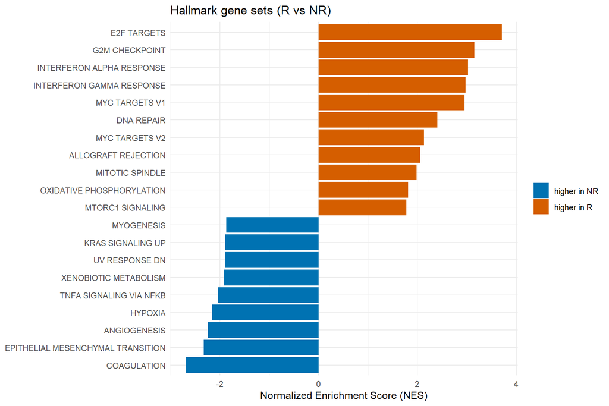

```r
# Function: bar plot of NES for the 20 most significant gene sets
plot_nes <- function(res, title) {
  top <- head(res[order(padj)], 20)
  top$label <- gsub("_", " ", sub("^HALLMARK_|^GOBP_", "", top$pathway))  # cleaner names
  ggplot(top, aes(x = reorder(label, NES), y = NES, fill = NES > 0)) +
    geom_col() + coord_flip() +
    scale_fill_manual(values = c("TRUE" = "#D55E00", "FALSE" = "#0072B2"),
                      labels = c("TRUE" = "higher in R", "FALSE" = "higher in NR"), name = NULL) +
    labs(x = NULL, y = "Normalized Enrichment Score (NES)", title = title) +
    theme_minimal()
}

# Hallmark: NES bar plot of the top 20 gene sets
p_h <- plot_nes(gsea_h, "Hallmark gene sets (R vs NR)")
ggsave("results/figures/gsea_hallmark_nes.png", p_h, width = 8, height = 6, dpi = 300)
p_h
```

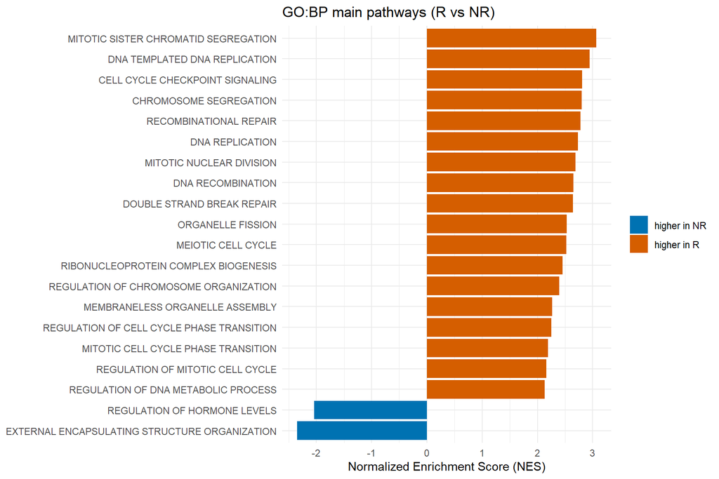

```r
# GO:BP: NES bar plot of the top 20 main pathways
p_bp <- plot_nes(bp_main, "GO:BP main pathways (R vs NR)")
ggsave("results/figures/gsea_gobp_main_nes.png", p_bp, width = 9, height = 6, dpi = 300)
p_bp
```

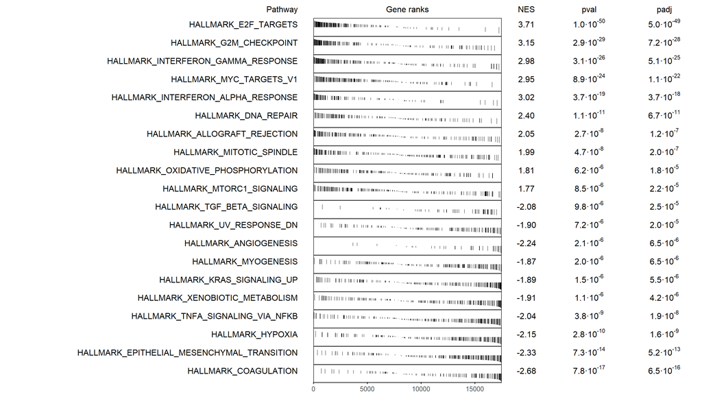

```r
# GSEA table: top 10 Hallmark sets higher in R and top 10 higher in NR
top_up   <- gsea_h[NES > 0][head(order(pval), n = 10), pathway]
top_down <- gsea_h[NES < 0][head(order(pval), n = 10), pathway]
top_tab  <- c(top_up, rev(top_down))
plotGseaTable(gene_sets_h[top_tab], stats = ranks, fgseaRes = gsea_h, gseaParam = 0.5)
```

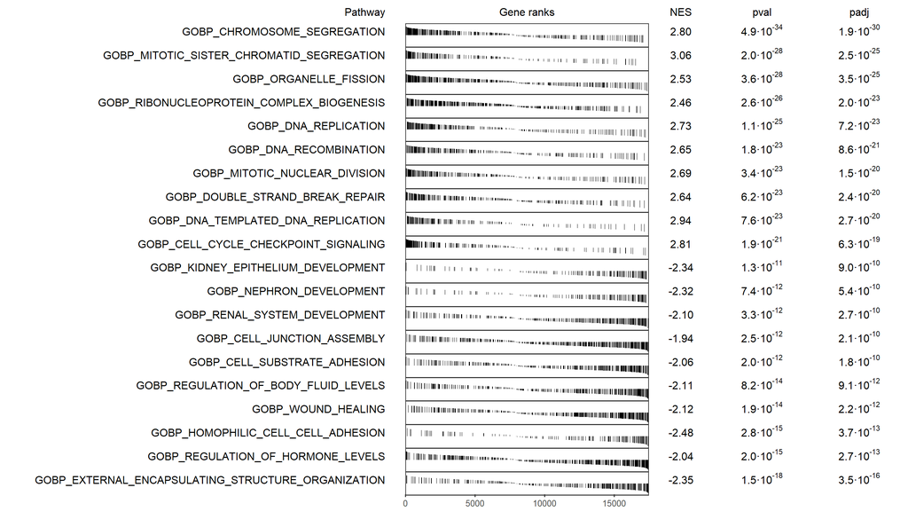

```r
# GSEA table: top 10 GO:BP main pathways higher in R and top 10 higher in NR
top_up   <- bp_main[NES > 0][head(order(pval), n = 10), pathway]
top_down <- bp_main[NES < 0][head(order(pval), n = 10), pathway]
top_tab  <- c(top_up, rev(top_down))
plotGseaTable(gene_sets_bp[top_tab], stats = ranks, fgseaRes = gsea_bp, gseaParam = 0.5)
```

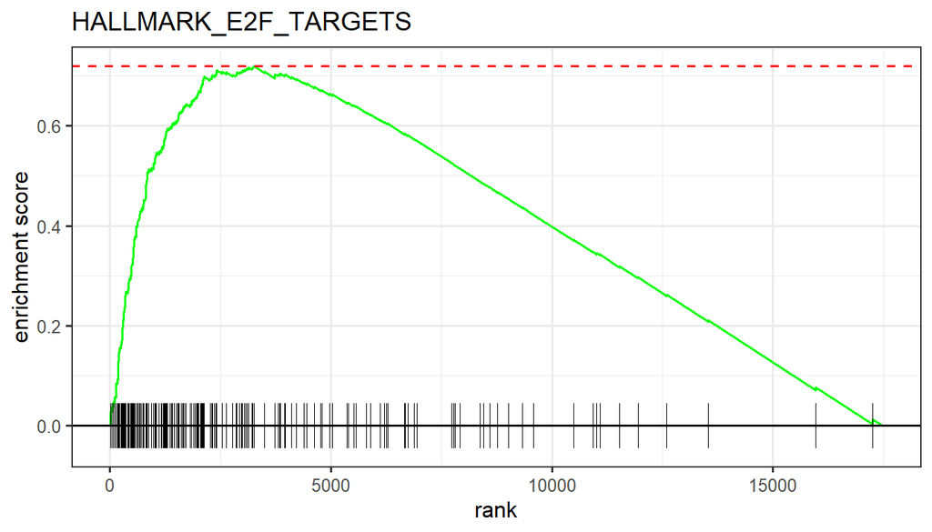

```r
# Enrichment curve of the most significant pathway
top_h_pw  <- gsea_h[order(padj)][1, pathway]
top_bp_pw <- gsea_bp[order(padj)][1, pathway]

p_curve_h <- plotEnrichment(gene_sets_h[[top_h_pw]], ranks) + labs(title = top_h_pw)
p_curve_bp <- plotEnrichment(gene_sets_bp[[top_bp_pw]], ranks) + labs(title = top_bp_pw)

ggsave("results/figures/gsea_curve_top_hallmark.png", p_curve_h,  width = 7, height = 4, dpi = 300)
ggsave("results/figures/gsea_curve_top_gobp.png",     p_curve_bp, width = 7, height = 4, dpi = 300)
p_curve_h
```

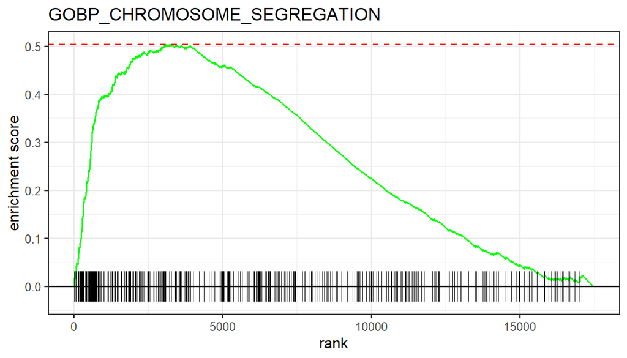

```r
p_curve_bp
```